# Exploring the BRFSS data

## Setup

### Load packages

```r
library(ggplot2)
library(dplyr)
```

### Load data

```r
load("brfss2013.Rdata")
```

## Part 1: Data

Data is collected by phone, uniformly at random among landlord adults (>= 18 years old) in the US. Thus the study excludes homeless people, who may be especially concerned with risk behaviors. Additional data was added in 2013 for young people. Moreover, I guess that only people who responded to phone are taken into account. Thus the study is not generalizable to the whole population, but only to a subset of it.

Since there is no random assignment, this is an observational study and no causality can be proven, only correlation.

## Part 2: Research questions

**Research quesion 1:** Is there any correlation between chccopd1 (Chronic Obstructive Pulmonary Disease) and smokday2 (Frequency Of Days Now Smoking)?

**Research quesion 2:** Is there any correlation between sleep time (sleptim1) of men and women (based on the sex variable) and the number of children (children)?

**Research quesion 3:** How are physical exercise (exerany2) and mental/physical health related?

## Part 3: Exploratory data analysis

**Research quesion 1:**

Let’s see the number and percentage of Chronic Obstructive Pulmonary Disease among smokers and non-smokers:

```r
table(brfss2013$smokday2, brfss2013$chccopd1)
```

```
##
##                 Yes     No
##   Every day    9999  44747
##   Some days    3186  18163
##   Not at all  16746 120536
```

The amount of data collected seems enough to be significant.

```r
prop.table(table(brfss2013$smokday2, brfss2013$chccopd1), margin = 1)
```

```
##
##                    Yes        No
##   Every day  0.1826435 0.8173565
##   Some days  0.1492342 0.8507658
##   Not at all 0.1219825 0.8780175
```

This is also confirmed visually by the following percentage bar plot:

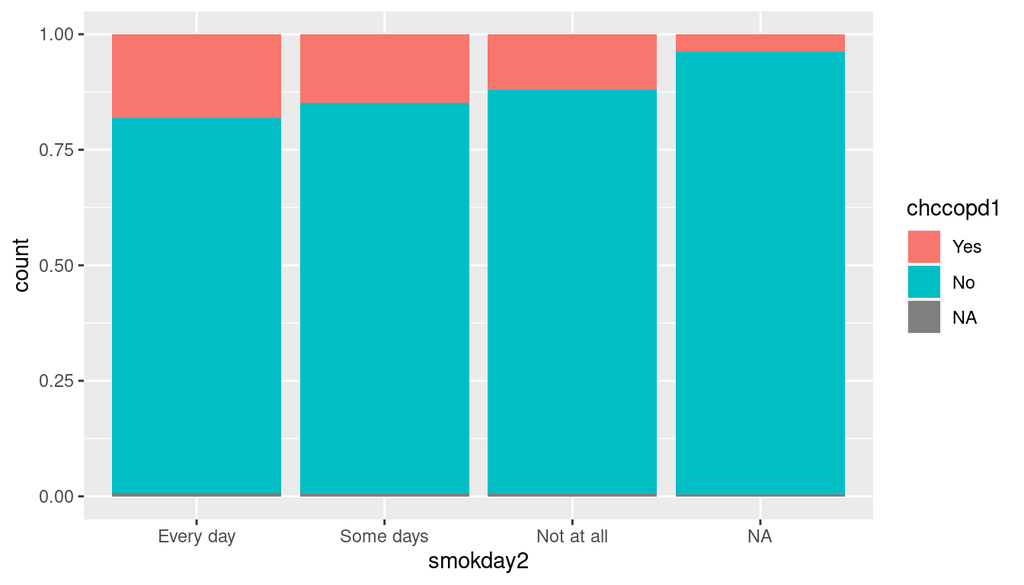

```r
ggplot(brfss2013, aes(x=smokday2, fill = chccopd1)) +
  geom_bar(position="fill")
```

**Research question 2:** Let’s see some statistics about sleep time:

```r
summary(brfss2013$sleptim1)
```

```
##    Min. 1st Qu.  Median    Mean 3rd Qu.    Max.    NA's
##   0.000   6.000   7.000   7.052   8.000 450.000    7387
```

We can see that some people reported very unusual sleep time (450 hours per day…), we remove those anomalies:

```r
brfss2013 <- subset(brfss2013, sleptim1 <= 24)
```

```r
t <- table(brfss2013$sleptim1, brfss2013$children)
d <- data.frame("Sleep" = brfss2013$sleptim1, "Children" = brfss2013$children, "Sex" = brfss2013$sex)
d <- subset(d, Children < 10) # we remove the very high number of children since there are uninformative (too few of data)
d <- (d %>% group_by(Children, Sex) %>% summarise(MeanSleep = mean(Sleep), n = n(), .groups = 'drop'))
summary(d)
```

```
##     Children         Sex       MeanSleep           n
##  Min.   :0.000   Male  :10   Min.   :6.424   Min.   :     1
##  1st Qu.:2.000   Female:10   1st Qu.:6.739   1st Qu.:   100
##  Median :4.000   NA's  : 1   Median :6.809   Median :  1278
##  Mean   :4.429               Mean   :6.850   Mean   : 22961
##  3rd Qu.:7.000               3rd Qu.:6.912   3rd Qu.: 18900
##  Max.   :9.000               Max.   :8.000   Max.   :206845
```

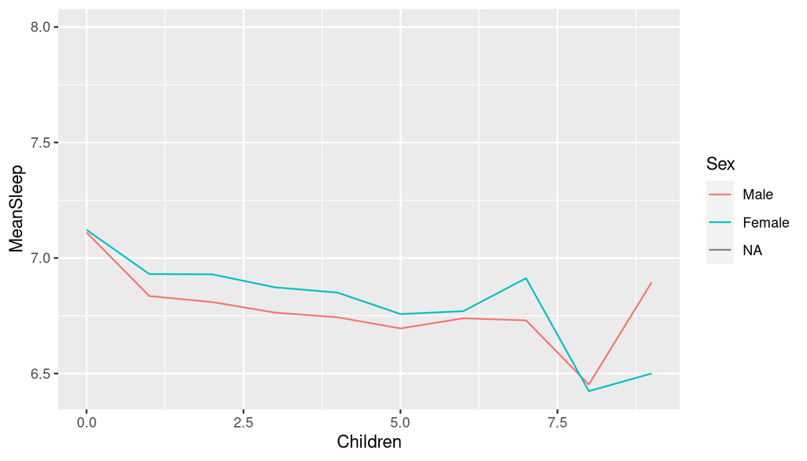

```r
ggplot(d, aes(x=Children, y=MeanSleep, color = Sex)) +
  geom_line()
```

This curve tends to indicate that having children reduces someone’s sleep time, especially with the first child. For a high number of childs, there is not enough data. Men and women have similar sleep duration, but women seems to sleep slighty more.

**Research quesion 3:** Let’s compare the average number of days in bad physical/mental health conditions:

```r
df <- brfss2013 %>% group_by(exerany2) %>% summarise(PhysHealth = mean(physhlth, na.rm=TRUE), MentalHealth = mean(menthlth, na.rm=TRUE), n = n(), .groups = 'drop')
df
```

```
## # A tibble: 3 x 4
##   exerany2 PhysHealth MentalHealth      n
##   <fct>         <dbl>        <dbl>  <int>
## 1 Yes            3.20         2.82 329121
## 2 No             7.29         4.72 122256
## 3 <NA>           4.30         3.43  33009
```

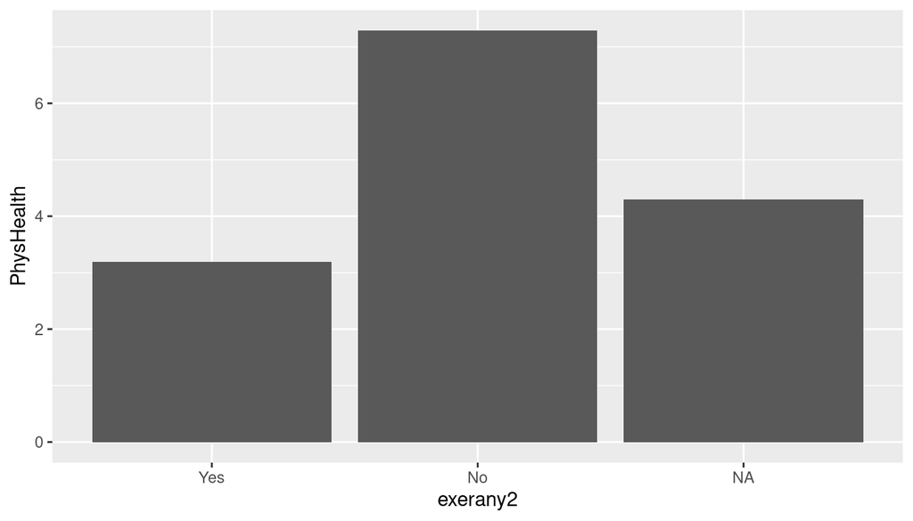

```r
ggplot(df, aes(x=exerany2, y = PhysHealth)) + geom_bar(stat="identity")
```

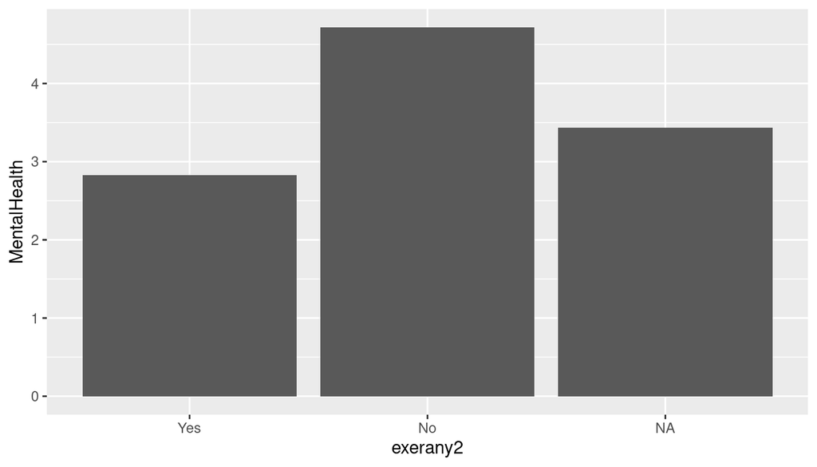

```r
ggplot(df, aes(x=exerany2, y = MentalHealth)) + geom_bar(stat="identity")
```

The absence of physical exercise is highly correlated with bad physical health and mental health. However it is difficult to conclude about any causal possibility: maybe bad physical health cause people to do less exercise, maybe less exercice means worse health, or maybe there is correlation without causation.